# ExtraaLearn Project

## Context

The EdTech industry has been surging in the past decade immensely, and according to a forecast, the Online Education market would be worth $286.62bn by 2023 with a compound annual growth rate (CAGR) of 10.26% from 2018 to 2023. The modern era of online education has enforced a lot in its growth and expansion beyond any limit. Due to having many dominant features like ease of information sharing, personalized learning experience, transparency of assessment, etc, it is now preferable to traditional education.

In the present scenario due to the Covid-19, the online education sector has witnessed rapid growth and is attracting a lot of new customers. Due to this rapid growth, many new companies have emerged in this industry. With the availability and ease of use of digital marketing resources, companies can reach out to a wider audience with their offerings. The customers who show interest in these offerings are termed as leads. There are various sources of obtaining leads for Edtech companies, like

- The customer interacts with the marketing front on social media or other online platforms.
- The customer browses the website/app and downloads the brochure
- The customer connects through emails for more information.

The company then nurtures these leads and tries to convert them to paid customers. For this, the representative from the organization connects with the lead on call or through email to share further details.

## Objective

ExtraaLearn is an initial stage startup that offers programs on cutting-edge technologies to students and professionals to help them upskill/reskill. With a large number of leads being generated on a regular basis, one of the issues faced by ExtraaLearn is to identify which of the leads are more likely to convert so that they can allocate resources accordingly. You, as a data scientist at ExtraaLearn, have been provided the leads data to:

- Analyze and build an ML model to help identify which leads are more likely to convert to paid customers,
- Find the factors driving the lead conversion process
- Create a profile of the leads which are likely to convert

## Data Description

The data contains the different attributes of leads and their interaction details with ExtraaLearn. The detailed data dictionary is given below.

**Data Dictionary**

- ID: ID of the lead
- age: Age of the lead
- current_occupation: Current occupation of the lead. Values include 'Professional','Unemployed',and 'Student'
- first_interaction: How did the lead first interacted with ExtraaLearn. Values include 'Website', 'Mobile App'
- profile_completed: What percentage of profile has been filled by the lead on the website/mobile app. Values include Low - (0-50%), Medium - (50-75%), High (75-100%)
- website_visits: How many times has a lead visited the website
- time_spent_on_website: Total time spent on the website
- page_views_per_visit: Average number of pages on the website viewed during the visits.
- last_activity: Last interaction between the lead and ExtraaLearn.
  - Email Activity: Seeking for details about program through email, Representative shared information with lead like brochure of program , etc
  - Phone Activity: Had a Phone Conversation with representative, Had conversation over SMS with representative, etc
  - Website Activity: Interacted on live chat with representative, Updated profile on website, etc
- print_media_type1: Flag indicating whether the lead had seen the ad of ExtraaLearn in the Newspaper.
- print_media_type2: Flag indicating whether the lead had seen the ad of ExtraaLearn in the Magazine.
- digital_media: Flag indicating whether the lead had seen the ad of ExtraaLearn on the digital platforms.
- educational_channels: Flag indicating whether the lead had heard about ExtraaLearn in the education channels like online forums, discussion threads, educational websites, etc.
- referral: Flag indicating whether the lead had heard about ExtraaLearn through reference.
- status: Flag indicating whether the lead was converted to a paid customer or not.

## Importing necessary libraries and data

```python
import warnings

warnings.filterwarnings("ignore")
from statsmodels.tools.sm_exceptions import ConvergenceWarning

warnings.simplefilter("ignore", ConvergenceWarning)

# Libraries to help with reading and manipulating data

import pandas as pd
import numpy as np

# Library to split data
from sklearn.model_selection import train_test_split

# libaries to help with data visualization
import matplotlib.pyplot as plt
import seaborn as sns

# Removes the limit for the number of displayed columns
pd.set_option("display.max_columns", None)
# Sets the limit for the number of displayed rows
pd.set_option("display.max_rows", 200)
# setting the precision of floating numbers to 5 decimal points
pd.set_option("display.float_format", lambda x: "%.5f" % x)

# To build model for prediction
import statsmodels.stats.api as sms
from statsmodels.stats.outliers_influence import variance_inflation_factor
import statsmodels.api as sm
from statsmodels.tools.tools import add_constant
from sklearn.linear_model import LogisticRegression
from sklearn.tree import DecisionTreeClassifier
from sklearn import tree
from sklearn.ensemble import RandomForestClassifier

# To tune different models
from sklearn.model_selection import GridSearchCV


# To get diferent metric scores
import sklearn.metrics as metrics
from sklearn.metrics import (
    f1_score,
    accuracy_score,
    recall_score,
    precision_score,
    confusion_matrix,
    classification_report,
    roc_auc_score,
    precision_recall_curve,
    roc_curve,
    make_scorer,
)
%matplotlib inline
```

```python
from google.colab import drive
drive.mount('/content/drive')
```

```python
df = pd.read_csv('/content/drive/My Drive/ExtraaLearn.csv')
```

## Data Overview

- Observations
- Sanity checks

```python
data = df.copy()
```

```python
  data.head(8)
```

|  | ID | age | current_occupation | first_interaction | profile_completed | website_visits | time_spent_on_website | page_views_per_visit | last_activity | print_media_type1 | print_media_type2 | digital_media | educational_channels | referral | status |
| --- | --- | --- | --- | --- | --- | --- | --- | --- | --- | --- | --- | --- | --- | --- | --- |
| 0 | EXT001 | 57 | Unemployed | Website | High | 7 | 1639 | 1.86100 | Website Activity | Yes | No | Yes | No | No | 1 |
| 1 | EXT002 | 56 | Professional | Mobile App | Medium | 2 | 83 | 0.32000 | Website Activity | No | No | No | Yes | No | 0 |
| 2 | EXT003 | 52 | Professional | Website | Medium | 3 | 330 | 0.07400 | Website Activity | No | No | Yes | No | No | 0 |
| 3 | EXT004 | 53 | Unemployed | Website | High | 4 | 464 | 2.05700 | Website Activity | No | No | No | No | No | 1 |
| 4 | EXT005 | 23 | Student | Website | High | 4 | 600 | 16.91400 | Email Activity | No | No | No | No | No | 0 |
| 5 | EXT006 | 50 | Unemployed | Mobile App | High | 4 | 212 | 5.68200 | Phone Activity | No | No | No | Yes | No | 0 |
| 6 | EXT007 | 56 | Professional | Mobile App | Medium | 13 | 625 | 2.01500 | Website Activity | No | No | Yes | No | No | 1 |
| 7 | EXT008 | 57 | Professional | Mobile App | Medium | 2 | 517 | 2.98500 | Email Activity | No | No | No | No | No | 0 |

```python
data.tail()
```

|  | ID | age | current_occupation | first_interaction | profile_completed | website_visits | time_spent_on_website | page_views_per_visit | last_activity | print_media_type1 | print_media_type2 | digital_media | educational_channels | referral | status |
| --- | --- | --- | --- | --- | --- | --- | --- | --- | --- | --- | --- | --- | --- | --- | --- |
| 4607 | EXT4608 | 35 | Unemployed | Mobile App | Medium | 15 | 360 | 2.17000 | Phone Activity | No | No | No | Yes | No | 0 |
| 4608 | EXT4609 | 55 | Professional | Mobile App | Medium | 8 | 2327 | 5.39300 | Email Activity | No | No | No | No | No | 0 |
| 4609 | EXT4610 | 58 | Professional | Website | High | 2 | 212 | 2.69200 | Email Activity | No | No | No | No | No | 1 |
| 4610 | EXT4611 | 57 | Professional | Mobile App | Medium | 1 | 154 | 3.87900 | Website Activity | Yes | No | No | No | No | 0 |
| 4611 | EXT4612 | 55 | Professional | Website | Medium | 4 | 2290 | 2.07500 | Phone Activity | No | No | No | No | No | 0 |

```python
data.info()
```

```
<class 'pandas.core.frame.DataFrame'>
RangeIndex: 4612 entries, 0 to 4611
Data columns (total 15 columns):
 #   Column                 Non-Null Count  Dtype
---  ------                 --------------  -----
 0   ID                     4612 non-null   object
 1   age                    4612 non-null   int64
 2   current_occupation     4612 non-null   object
 3   first_interaction      4612 non-null   object
 4   profile_completed      4612 non-null   object
 5   website_visits         4612 non-null   int64
 6   time_spent_on_website  4612 non-null   int64
 7   page_views_per_visit   4612 non-null   float64
 8   last_activity          4612 non-null   object
 9   print_media_type1      4612 non-null   object
 10  print_media_type2      4612 non-null   object
 11  digital_media          4612 non-null   object
 12  educational_channels   4612 non-null   object
 13  referral               4612 non-null   object
 14  status                 4612 non-null   int64
dtypes: float64(1), int64(4), object(10)
memory usage: 540.6+ KB
```

```python
missing_values = data.isnull().sum()
missing_values # returns the count of null values by column index and since the values are zero, there are no null values in the dataset.
```

```
ID                       0
age                      0
current_occupation       0
first_interaction        0
profile_completed        0
website_visits           0
time_spent_on_website    0
page_views_per_visit     0
last_activity            0
print_media_type1        0
print_media_type2        0
digital_media            0
educational_channels     0
referral                 0
status                   0
dtype: int64
```

```python
data.duplicated().sum() #data = data.drop_duplicates() if there are any duplicates encountered. Since there are none encountered, this command is not required.
```

```
0
```

```python
data.nunique()
```

```
ID                       4612
age                        46
current_occupation          3
first_interaction           2
profile_completed           3
website_visits             27
time_spent_on_website    1623
page_views_per_visit     2414
last_activity               3
print_media_type1           2
print_media_type2           2
digital_media               2
educational_channels        2
referral                    2
status                      2
dtype: int64
```

```python
data.drop(["ID"], axis = 1, inplace = True) #This column is dropped as we determine it is not important in our evaluation due to the uniqueness of each ID.
```

Observations: ID is an identifier which is unique for each lead. We can drop this column since it would provide no value to the analysis.

## Exploratory Data Analysis (EDA)

- EDA is an important part of any project involving data.
- It is important to investigate and understand the data better before building a model with it.
- A few questions have been mentioned below which will help you approach the analysis in the right manner and generate insights from the data.
- A thorough analysis of the data, in addition to the questions mentioned below, should be done.

**Questions**

1. Leads will have different expectations from the outcome of the course and the current occupation may play a key role in getting them to participate in the program. Find out how current occupation affects lead status.
2. The company's first impression on the customer must have an impact. Do the first channels of interaction have an impact on the lead status?
3. The company uses multiple modes to interact with prospects. Which way of interaction works best?
4. The company gets leads from various channels such as print media, digital media, referrals, etc. Which of these channels have the highest lead conversion rate?
5. People browsing the website or mobile application are generally required to create a profile by sharing their personal data before they can access additional information.Does having more details about a prospect increase the chances of conversion?

```python
#creating numerical columns
num_cols = ['age','website_visits','time_spent_on_website','page_views_per_visit']
#creating categorical columns
cat_cols = ['current_occupation','first_interaction','profile_completed','last_activity','print_media_type1','print_media_type2','digital_media','educational_channels','referral','status']
```

```python
data[num_cols].describe().T
```

|  | count | mean | std | min | 25% | 50% | 75% | max |
| --- | --- | --- | --- | --- | --- | --- | --- | --- |
| age | 4612.00000 | 46.20121 | 13.16145 | 18.00000 | 36.00000 | 51.00000 | 57.00000 | 63.00000 |
| website_visits | 4612.00000 | 3.56678 | 2.82913 | 0.00000 | 2.00000 | 3.00000 | 5.00000 | 30.00000 |
| time_spent_on_website | 4612.00000 | 724.01127 | 743.82868 | 0.00000 | 148.75000 | 376.00000 | 1336.75000 | 2537.00000 |
| page_views_per_visit | 4612.00000 | 3.02613 | 1.96812 | 0.00000 | 2.07775 | 2.79200 | 3.75625 | 18.43400 |

Observations: Average lead age is 46.201. With range = 63-18= 45 50% of leads spend 376 seconds on the website. However there are some extreme values given that max is 2537 seconds and min being 0. Average number of pages on the website viewed during the visits is 3.026, and the average number of times a lead has visited the website is 3.567.

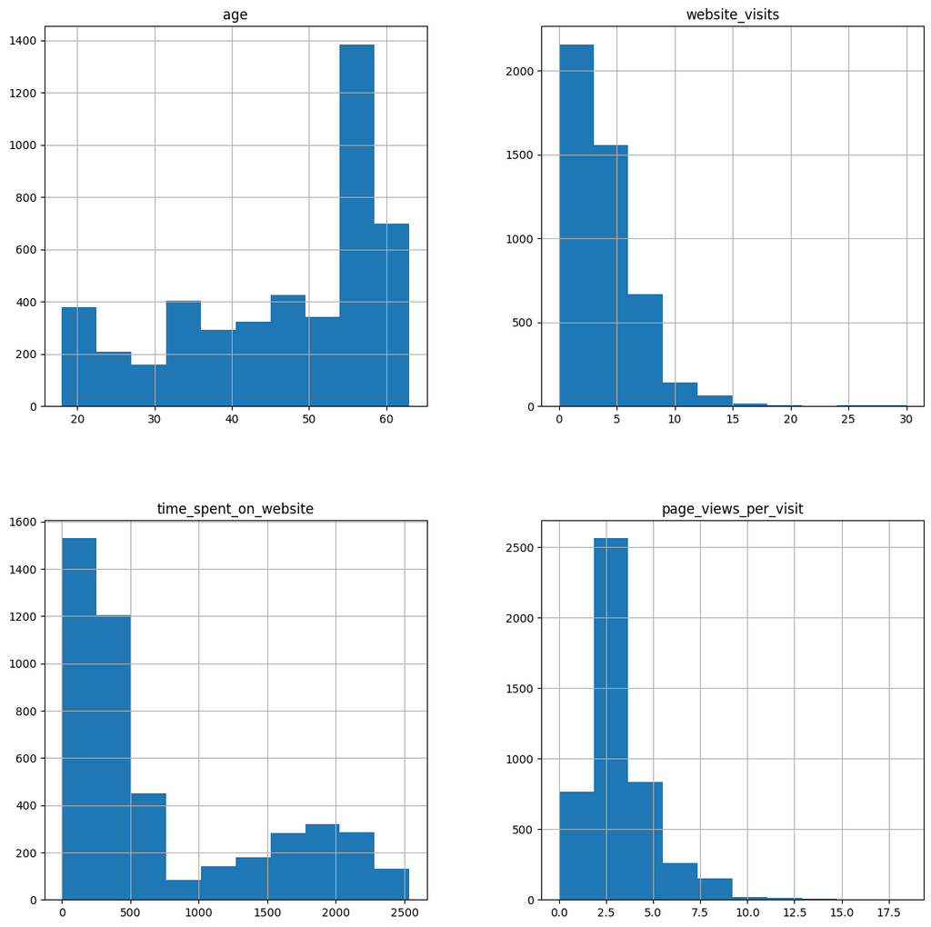

```python
# Creating histograms
data[num_cols].hist(figsize=(14,14))
plt.show()
```

Observations: The number of leads wrt age is skewed left. This indicates that leads are increasing wrt age. And leads wrt website_visits is skewed right.Indicating that the frequency of number of leads decrease as number of visits increase. Time spent on the website has a bimodal structure with peaks at 0-250 then at 1750-2000 seconds spent online, and the central tendency of page views per visit is narrow and skewed slightly to the right. It would be closer to the normal distribution had the variance been greater than current value. The peak for the page_views_per_visit is at 1.875-3.75 pages.

## Univariate Analysis

```python
for column in cat_cols:
    print(data[column].value_counts(normalize = True)) #we can leave the normalize parameter out of the statement is we want to display raw counts.
    print("-" * 50)
```

```
Professional   0.56722
Unemployed     0.31245
Student        0.12034
Name: current_occupation, dtype: float64
--------------------------------------------------
Website      0.55117
Mobile App   0.44883
Name: first_interaction, dtype: float64
--------------------------------------------------
High     0.49089
Medium   0.48591
Low      0.02320
Name: profile_completed, dtype: float64
--------------------------------------------------
Email Activity     0.49393
Phone Activity     0.26756
Website Activity   0.23851
Name: last_activity, dtype: float64
--------------------------------------------------
No    0.89224
Yes   0.10776
Name: print_media_type1, dtype: float64
--------------------------------------------------
No    0.94948
Yes   0.05052
Name: print_media_type2, dtype: float64
--------------------------------------------------
No    0.88573
Yes   0.11427
Name: digital_media, dtype: float64
--------------------------------------------------
No    0.84714
Yes   0.15286
Name: educational_channels, dtype: float64
--------------------------------------------------
No    0.97984
Yes   0.02016
Name: referral, dtype: float64
--------------------------------------------------
0   0.70143
1   0.29857
Name: status, dtype: float64
--------------------------------------------------
```

Observations: The status conversion rate (yes) is 29.86%. Around 57.00% of the leads are of the professional background. Website proportions are greater than mobile app proportions which can hint at a higher engaement level on the website. Out of all the last_activity interactions, the email activity has more leads than its counterparts. Most leads have high-medium profile completion. Out of all the four channels and the referral section, the educational channel has the preferred mode of interaction.

## Bivariate and Multivariate Analysis

How is the conversion rate related to other categorical variables?

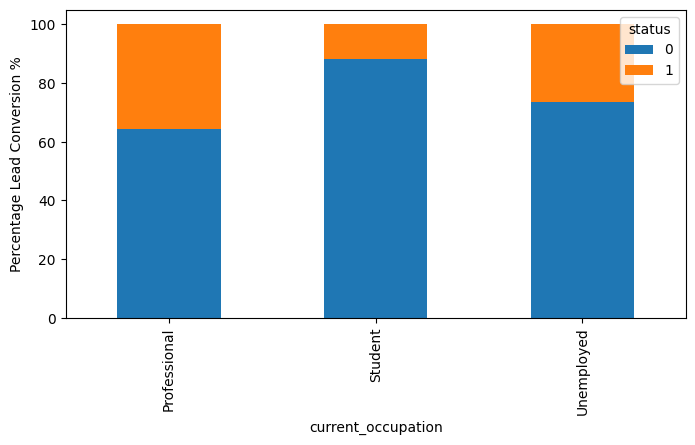

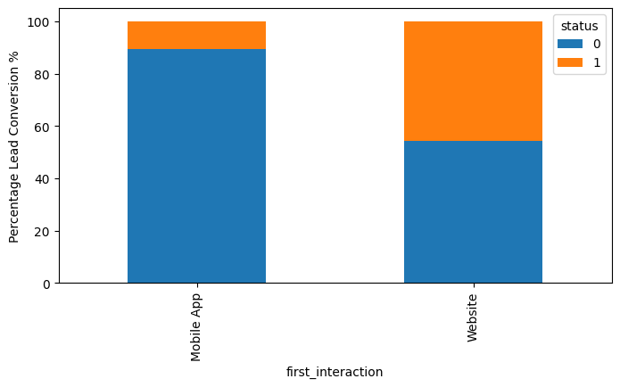

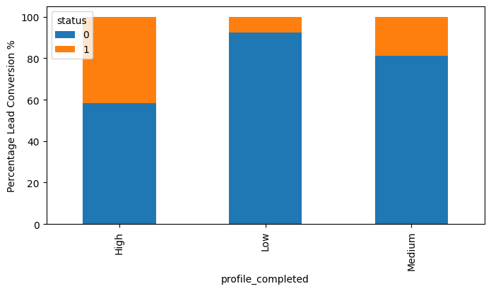

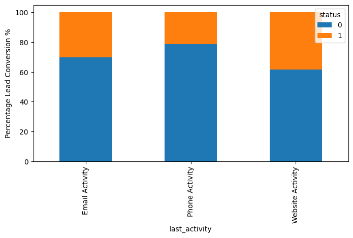

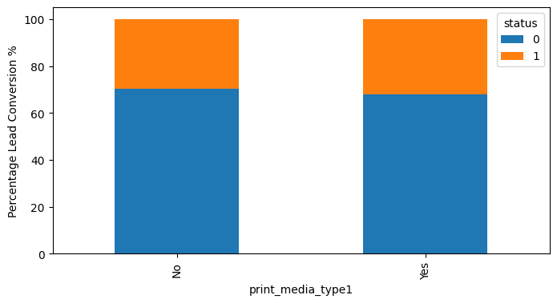

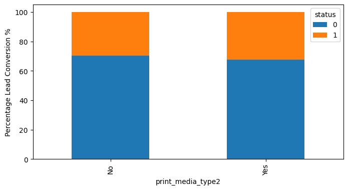

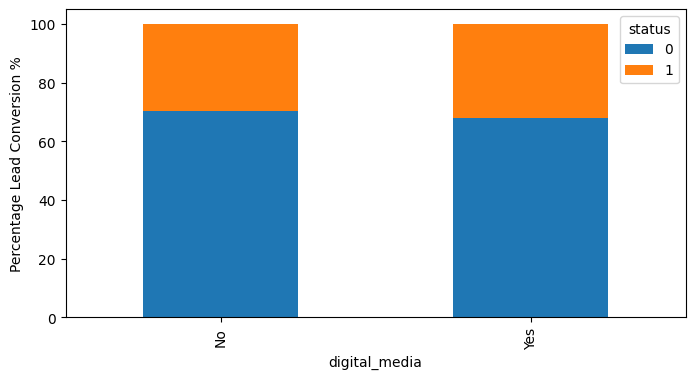

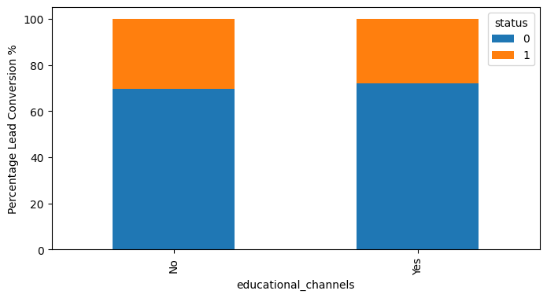

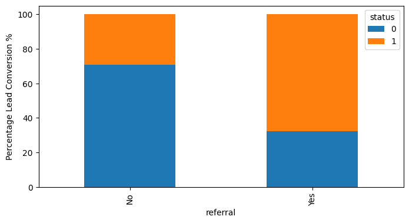

```python
for i in cat_cols:
    if i!='status':
        (pd.crosstab(data[i],data['status'],normalize='index')*100).plot(kind='bar',figsize=(8,4),stacked=True)
        plt.ylabel('Percentage Lead Conversion %')
```

```python
# Mean of numerical variables grouped by status
data.groupby(['status'])[num_cols].mean()
```

| status | age | website_visits | time_spent_on_website | page_views_per_visit |
| --- | --- | --- | --- | --- |
| 0 | 45.15301 | 3.57898 | 577.42071 | 3.02573 |
| 1 | 48.66376 | 3.53813 | 1068.39797 | 3.02705 |

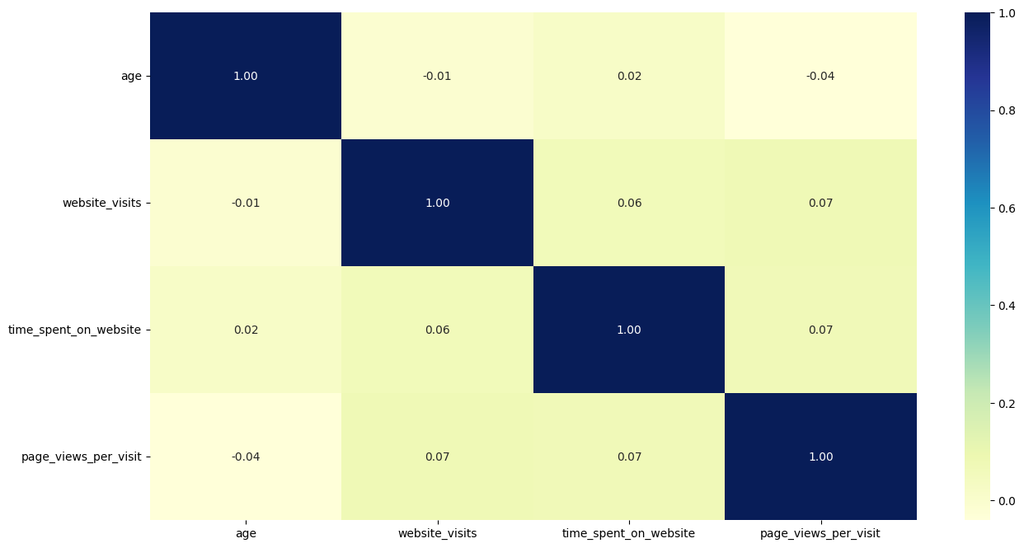

```python
# Plotting the correlation between numerical variables
plt.figure(figsize=(15,8))
sns.heatmap(data[num_cols].corr(),annot=True, fmt='0.2f', cmap='YlGnBu')
```

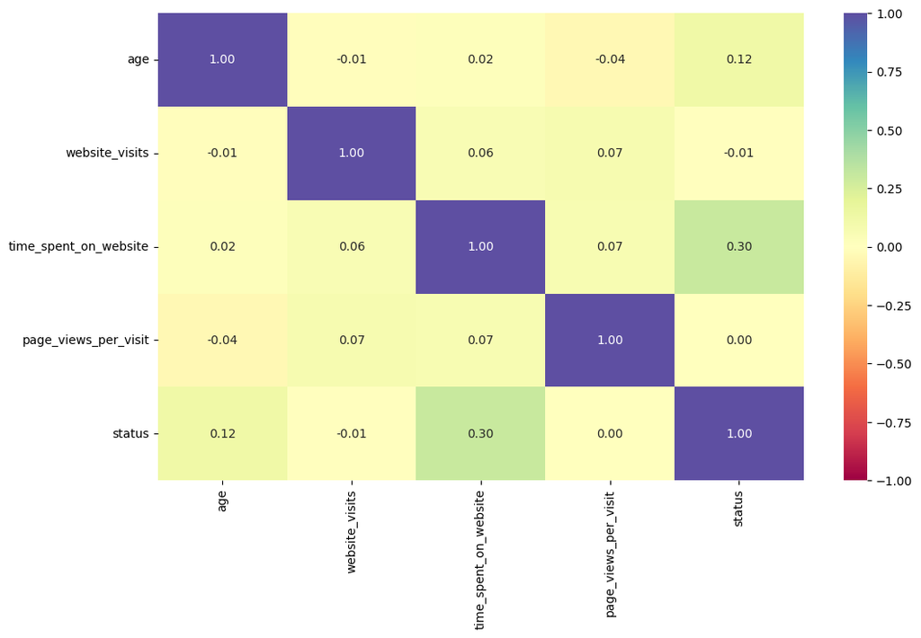

```python
cols_list = data.select_dtypes(include=np.number).columns.tolist()

plt.figure(figsize=(12, 7))
sns.heatmap(
    data[cols_list].corr(), annot=True, vmin=-1, vmax=1, fmt=".2f", cmap="Spectral"
)
plt.show()
```

## Further Univariate Analysis

```python
# function to plot a boxplot and a histogram along the same scale.

def histogram_boxplot(data, feature, figsize=(12, 7), kde=False, bins=None):
    """
    Boxplot and histogram combined

    data: dataframe
    feature: dataframe column
    figsize: size of figure (default (12,7))
    kde: whether to the show density curve (default False)
    bins: number of bins for histogram (default None)
    """
    f2, (ax_box2, ax_hist2) = plt.subplots(
        nrows=2,  # Number of rows of the subplot grid= 2
        sharex=True,  # x-axis will be shared among all subplots
        gridspec_kw={"height_ratios": (0.25, 0.75)},
        figsize=figsize,
    )  # creating the 2 subplots
    sns.boxplot(
        data=data, x=feature, ax=ax_box2, showmeans=True, color="violet"
    )  # boxplot will be created and a star will indicate the mean value of the column
    sns.histplot(
        data=data, x=feature, kde=kde, ax=ax_hist2, bins=bins, palette="winter"
    ) if bins else sns.histplot(
        data=data, x=feature, kde=kde, ax=ax_hist2
    )  # For histogram
    ax_hist2.axvline(
        data[feature].mean(), color="green", linestyle="--"
    )  # Add mean to the histogram
    ax_hist2.axvline(
        data[feature].median(), color="black", linestyle="-"
    )  # Add median to the histogram
```

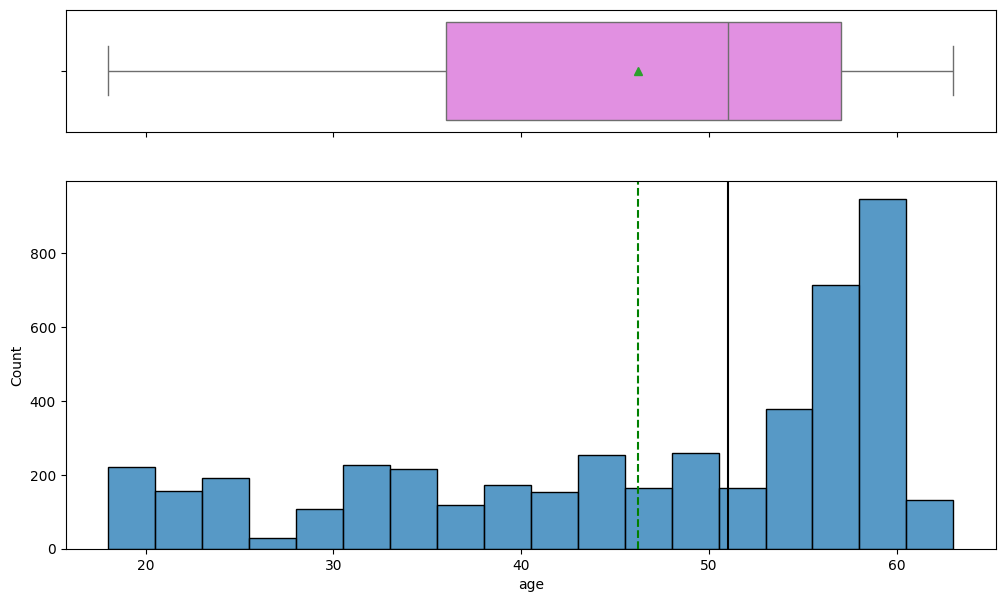

```python
histogram_boxplot(data, "age")
```

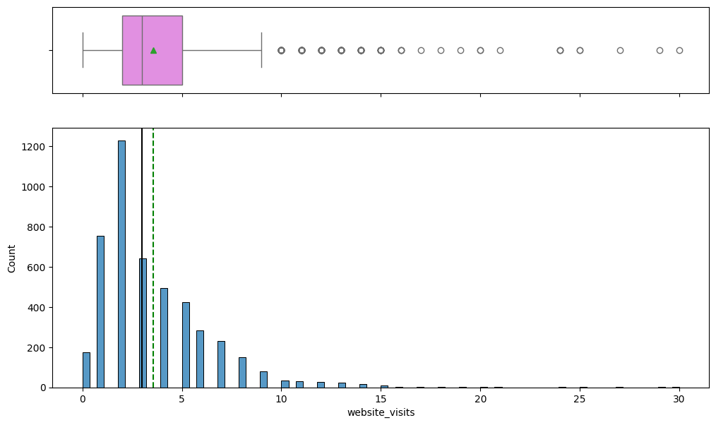

```python
histogram_boxplot(data, "website_visits")
```

Observation: Has more outliers given that it is skewed heavily to the right.

```python
data[data["website_visits"] == 0].shape
```

```
(174, 14)
```

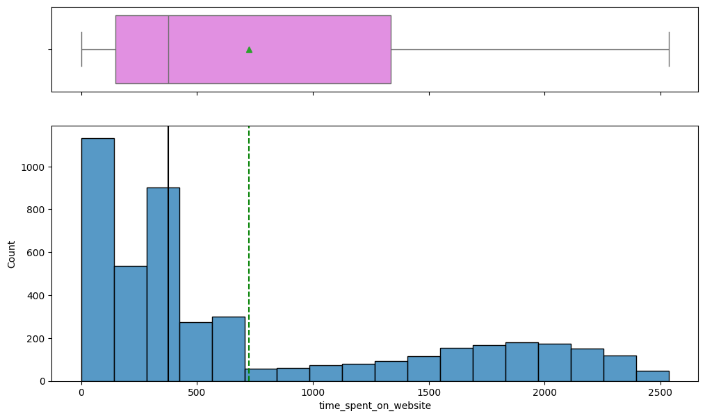

```python
histogram_boxplot(data, "time_spent_on_website")
```

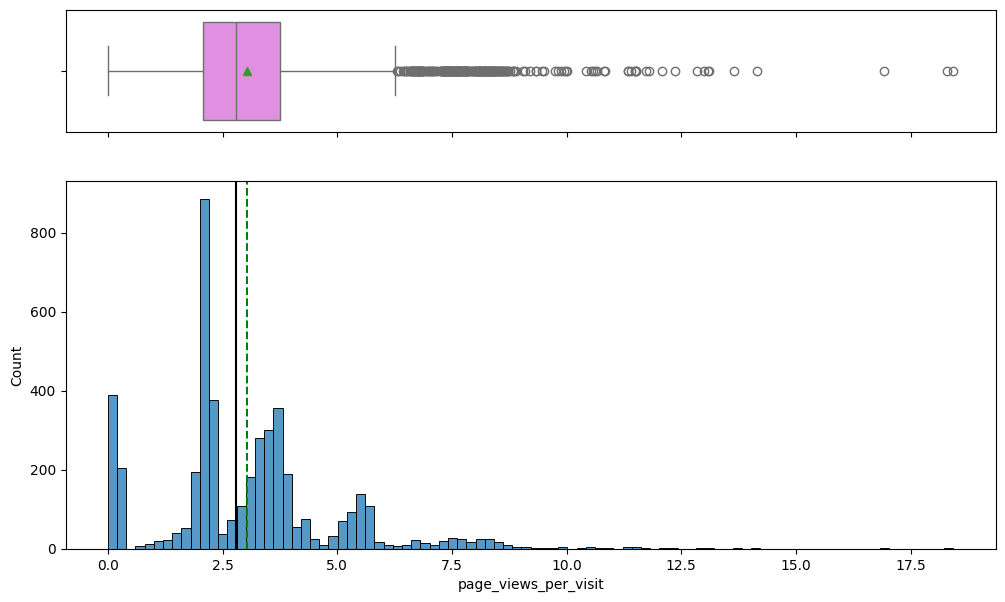

```python
histogram_boxplot(data, "page_views_per_visit")
```

Observation: the number of outliers in this feature is highest amongst all the numerical distributions

### Current Occupation and Lead Status

```python
data.columns
```

```
Index(['age', 'current_occupation', 'first_interaction', 'profile_completed',
       'website_visits', 'time_spent_on_website', 'page_views_per_visit',
       'last_activity', 'print_media_type1', 'print_media_type2',
       'digital_media', 'educational_channels', 'referral', 'status'],
      dtype='object')
```

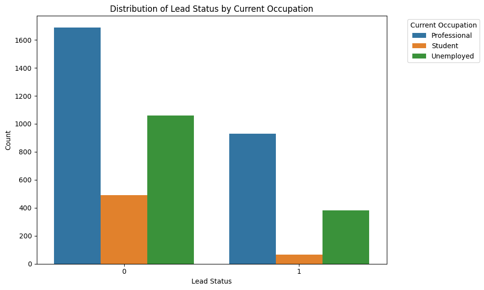

```python
plt.figure(figsize=(10, 6))
sns.countplot(data=data, x='status', hue='current_occupation')
plt.title('Distribution of Lead Status by Current Occupation')
plt.xlabel('Lead Status')
plt.ylabel('Count')
plt.legend(title='Current Occupation', bbox_to_anchor=(1.05, 1), loc='upper left')
plt.tight_layout()
plt.show()
```

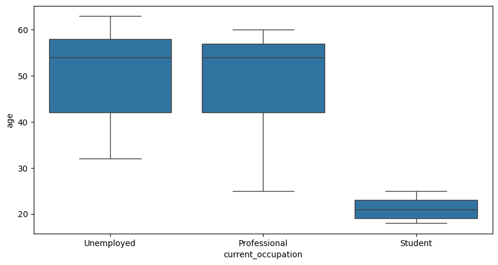

```python
plt.figure(figsize=(10, 5))
sns.boxplot(data = data, x = data["current_occupation"], y = data["age"])
plt.show()
```

```python
data.groupby(["current_occupation"])["age"].describe()
```

| current_occupation | count | mean | std | min | 25% | 50% | 75% | max |
| --- | --- | --- | --- | --- | --- | --- | --- | --- |
| Professional | 2616.00000 | 49.34748 | 9.89074 | 25.00000 | 42.00000 | 54.00000 | 57.00000 | 60.00000 |
| Student | 555.00000 | 21.14414 | 2.00111 | 18.00000 | 19.00000 | 21.00000 | 23.00000 | 25.00000 |
| Unemployed | 1441.00000 | 50.14018 | 9.99950 | 32.00000 | 42.00000 | 54.00000 | 58.00000 | 63.00000 |

```python
def distribution_plot_wrt_target(data, predictor, target):

    fig, axs = plt.subplots(2, 2, figsize=(12, 10))

    target_uniq = data[target].unique()

    axs[0, 0].set_title("Distribution of target for target=" + str(target_uniq[0]))
    sns.histplot(
        data=data[data[target] == target_uniq[0]],
        x=predictor,
        kde=True,
        ax=axs[0, 0],
        color="teal",
        stat="density",
    )

    axs[0, 1].set_title("Distribution of target for target=" + str(target_uniq[1]))
    sns.histplot(
        data=data[data[target] == target_uniq[1]],
        x=predictor,
        kde=True,
        ax=axs[0, 1],
        color="orange",
        stat="density",
    )

    axs[1, 0].set_title("Boxplot w.r.t target")
    sns.boxplot(data=data, x=target, y=predictor, ax=axs[1, 0], palette="gist_rainbow")

    axs[1, 1].set_title("Boxplot (without outliers) w.r.t target")
    sns.boxplot(
        data=data,
        x=target,
        y=predictor,
        ax=axs[1, 1],
        showfliers=False,
        palette="gist_rainbow",
    )

    plt.tight_layout()
    plt.show()
```

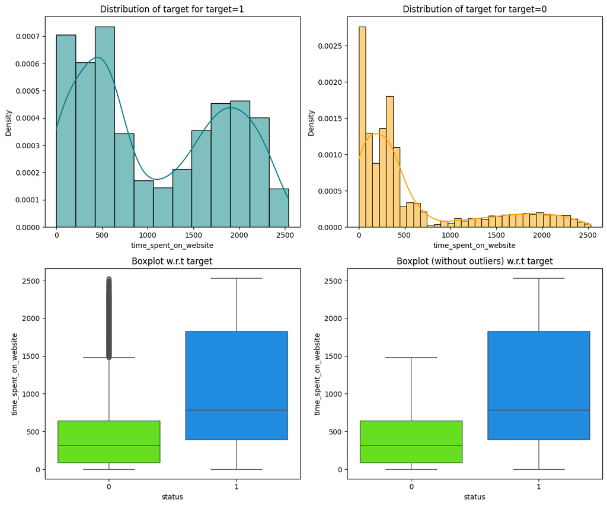

```python
distribution_plot_wrt_target(data, "time_spent_on_website", "status")
```

```python
data.groupby(["status"])["time_spent_on_website"].median()
```

```
status
0   317.00000
1   789.00000
Name: time_spent_on_website, dtype: float64
```

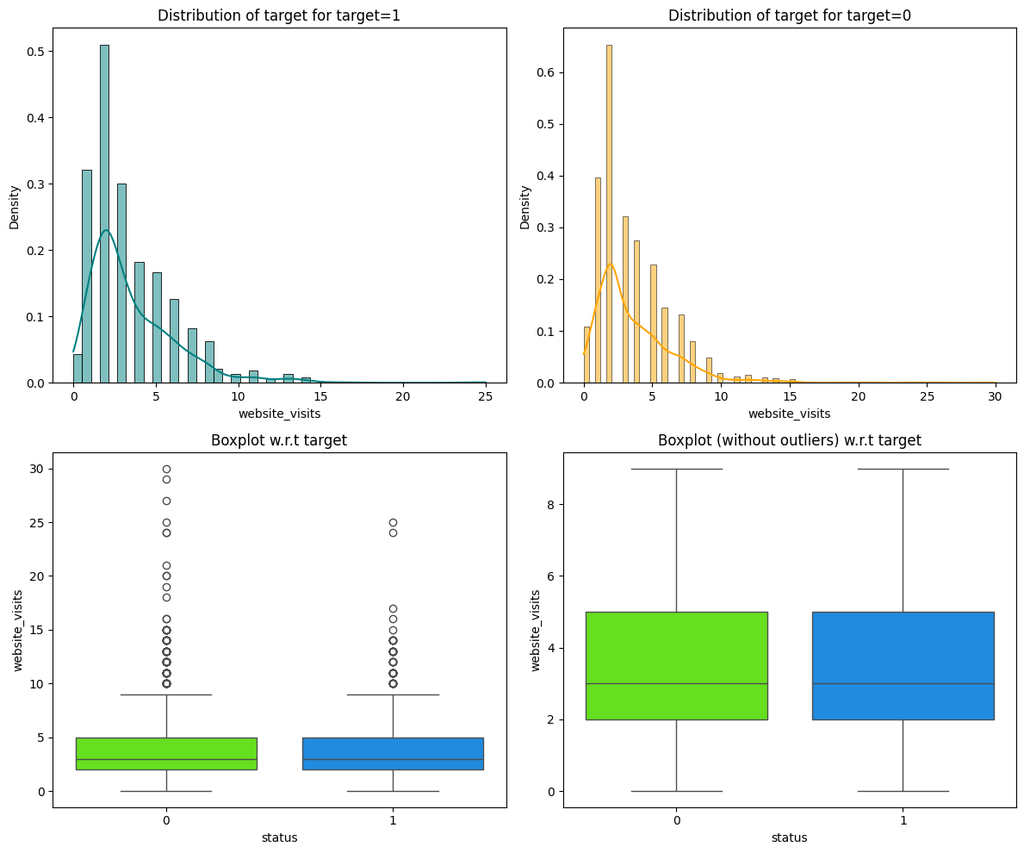

```python
distribution_plot_wrt_target(data, "website_visits", "status")
```

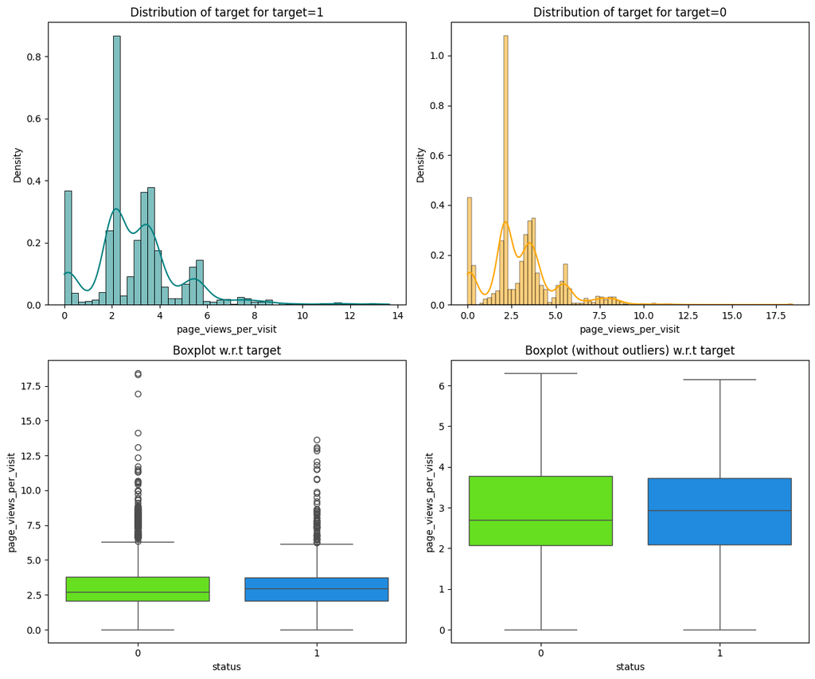

```python
distribution_plot_wrt_target(data, "page_views_per_visit", "status")
```

```python
conversion_rates = data.groupby('first_interaction')['status'].mean()
print(conversion_rates)
```

```
first_interaction
Mobile App   0.10531
Website      0.45594
Name: status, dtype: float64
```

```python
from scipy.stats import chi2_contingency

# Create a contingency table
contingency_table = pd.crosstab(data['first_interaction'], data['status'])

# Perform the chi-squared test
chi2, p, dof, expected = chi2_contingency(contingency_table)
print(f"Chi-Squared Value: {chi2}")
print(f"P-value: {p}")
```

```
Chi-Squared Value: 668.0813826411269
P-value: 2.611251831709229e-147
```

There is a significant association between the first channel of interaction and the lead conversion status as the p-value is lower than threshold.

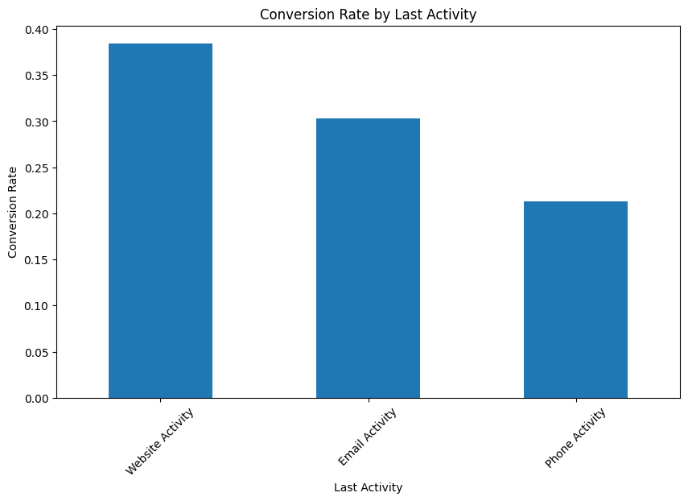

```python
# Calculate the conversion rate for each last activity type
conversion_rates = data.groupby('last_activity')['status'].mean().sort_values(ascending=False)

# Plot the conversion rates
conversion_rates.plot(kind='bar', figsize=(10, 6))
plt.title('Conversion Rate by Last Activity')
plt.xlabel('Last Activity')
plt.ylabel('Conversion Rate')
plt.xticks(rotation=45)
plt.show()
```

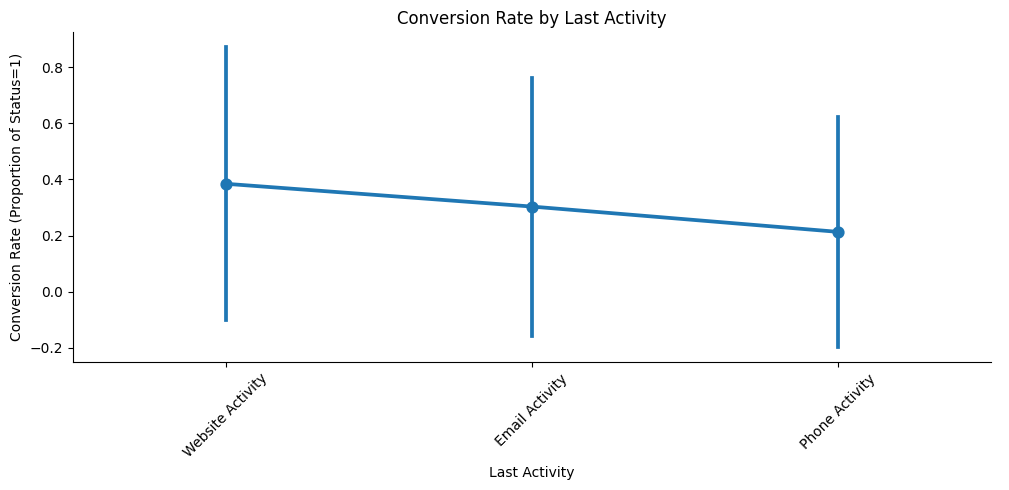

```python
sns.catplot(x='last_activity', y='status', data=data, kind='point', aspect=2, ci='sd')
plt.title('Conversion Rate by Last Activity')
plt.xlabel('Last Activity')
plt.ylabel('Conversion Rate (Proportion of Status=1)')
plt.xticks(rotation=45)
plt.tight_layout()
plt.show()
```

```python
# Calculate the conversion rate for each mode of interaction
modes_of_interaction = ['print_media_type1', 'print_media_type2', 'digital_media', 'educational_channels', 'referral']
# Convert 'Yes'/'No' to 1/0 for each mode
for mode in modes_of_interaction:
    data[mode] = data[mode].map({'Yes': 1, 'No': 0})
# Calculate the conversion rate for each mode
conversion_rates = {}
for mode in modes_of_interaction:
    # Calculate mean only for rows where the mode is 'Yes' (now converted to 1)
    rate = data[data[mode] == 1]['status'].mean()
    conversion_rates[mode] = rate

# Print conversion rates to verify calculations
print(conversion_rates)
```

```
{'print_media_type1': 0.3199195171026157, 'print_media_type2': 0.3218884120171674, 'digital_media': 0.3187855787476281, 'educational_channels': 0.2794326241134752, 'referral': 0.6774193548387096}
```

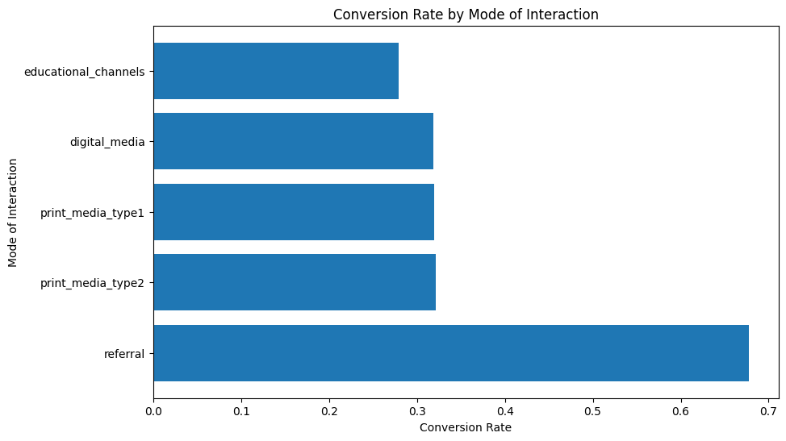

```python
# Convert the conversion rates to a DataFrame
conversion_rates_df = pd.DataFrame(list(conversion_rates.items()), columns=['Interaction_Mode', 'Conversion_Rate'])

# Plot the conversion rates
plt.figure(figsize=(10, 6))
conversion_rates_df = conversion_rates_df.sort_values('Conversion_Rate', ascending=False)
plt.barh(conversion_rates_df['Interaction_Mode'], conversion_rates_df['Conversion_Rate'])  # using horizontal bar plot for better readability
plt.xlabel('Conversion Rate')
plt.ylabel('Mode of Interaction')
plt.title('Conversion Rate by Mode of Interaction')
plt.show()
```

```python
# Now that the modes are binary, create the contingency table for the Chi-Squared test
contingency_table = pd.crosstab(index=data['status'], columns=[data['print_media_type1'],
                                                               data['print_media_type2'],
                                                               data['digital_media'],
                                                               data['educational_channels'],
                                                               data['referral']])
```

```python
from scipy.stats import chi2_contingency

# Apply the Chi-Squared test
chi2, p, dof, expected = chi2_contingency(contingency_table)

print(f"Chi-Squared Value: {chi2}")
print(f"P-value: {p}")
```

```
Chi-Squared Value: 89.99136488063837
P-value: 2.870313556108053e-09
```

There is a statistically significant difference in conversion rates across the different modes of interaction.

```python
# Assuming the dataset has a 'profile_completion' column with categories like 'Low', 'Medium', 'High'
conversion_rates_by_profile = data.groupby('profile_completed')['status'].mean()
```

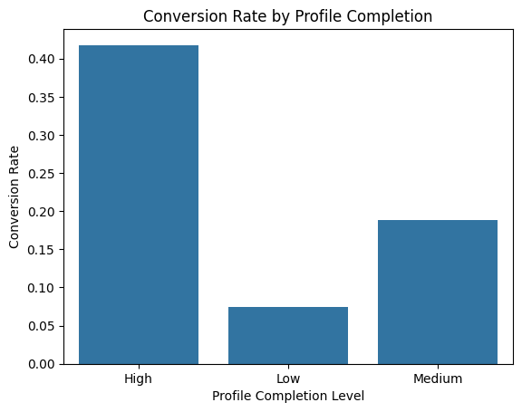

```python
sns.barplot(x=conversion_rates_by_profile.index, y=conversion_rates_by_profile.values)
plt.title('Conversion Rate by Profile Completion')
plt.xlabel('Profile Completion Level')
plt.ylabel('Conversion Rate')
plt.show()
```

```python
from scipy.stats import f_oneway

# Create groups for each profile completion category
group_low = data[data['profile_completed'] == 'Low']['status']
group_medium = data[data['profile_completed'] == 'Medium']['status']
group_high = data[data['profile_completed'] == 'High']['status']

# Perform ANOVA test
f_stat, p_value = f_oneway(group_low, group_medium, group_high)
print(f"F-statistic: {f_stat}")
print(f"P-value: {p_value}")
```

```
F-statistic: 165.15946022088713
P-value: 5.3198526686430796e-70
```

The results indicate that there are statistically significant differences in the conversion rates for different levels of profile completion.

## Data Preprocessing

- Missing value treatment (if needed)
- Feature engineering (if needed)
- Outlier detection and treatment (if needed)
- Preparing data for modeling
- Any other preprocessing steps (if needed)

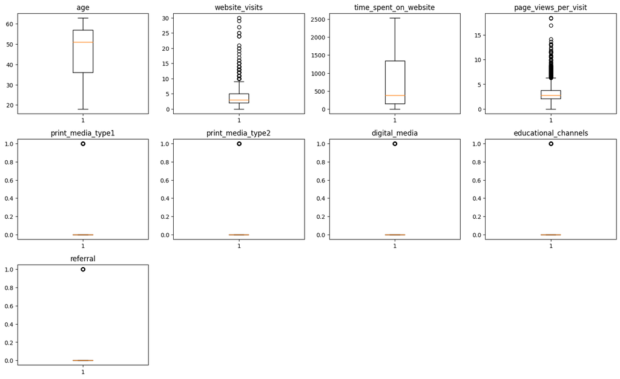

```python
# outlier detection using boxplot
numeric_columns = data.select_dtypes(include=np.number).columns.tolist()
# dropping release_year as it is a temporal variable
numeric_columns.remove("status")

plt.figure(figsize=(15, 12))

for i, variable in enumerate(numeric_columns):
    plt.subplot(4, 4, i + 1)
    plt.boxplot(data[variable], whis=1.5)
    plt.tight_layout()
    plt.title(variable)

plt.show()
```

```python
#Feature Engineering based on correlation for age and status and time-spent on website and status
data['engagement_score'] = (data['website_visits'] +
                                    data['time_spent_on_website'] +
                                    data['page_views_per_visit'])

data['age_engagement_interaction'] = data['age'] * data['engagement_score']
```

Feature scaling is not necessary for tree-based models like Decision Trees and Random Forests because these models do not rely on the scale or distribution of the features. They make decisions based on order (which item is larger) rather than on the specific scale of the feature values, meaning that the varying scales of the raw data do not affect these models' performance.

For decision tree models, including random forests, outliers will generally have less impact because these models are non-parametric—they do not make assumptions about the data distribution.

## EDA

- It is a good idea to explore the data once again after manipulating it.

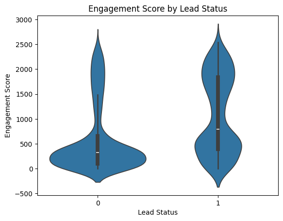

```python
sns.violinplot(x='status', y='engagement_score', data=data)
plt.title('Engagement Score by Lead Status')
plt.xlabel('Lead Status')
plt.ylabel('Engagement Score')
plt.show()
```

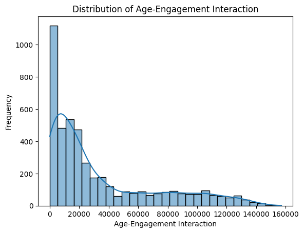

```python
sns.histplot(data['age_engagement_interaction'], kde=True)
plt.title('Distribution of Age-Engagement Interaction')
plt.xlabel('Age-Engagement Interaction')
plt.ylabel('Frequency')
plt.show()
```

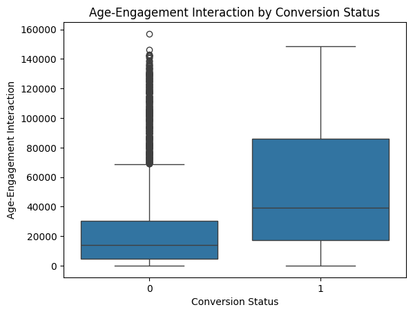

```python
sns.boxplot(x='status', y='age_engagement_interaction', data=data)
plt.title('Age-Engagement Interaction by Conversion Status')
plt.xlabel('Conversion Status')
plt.ylabel('Age-Engagement Interaction')
plt.show()
```

```python
print(data['age_engagement_interaction'].describe())
```

```
count     4612.00000
mean     33938.13910
std      37242.59161
min          0.00000
25%       5722.78575
50%      17973.47350
75%      52094.93200
max     157092.39000
Name: age_engagement_interaction, dtype: float64
```

```python
print(data[['age_engagement_interaction', 'status']].corr())
```

```
                            age_engagement_interaction  status
age_engagement_interaction                     1.00000 0.31954
status                                         0.31954 1.00000
```

## Outlier detection, treatment, and Data-split

```python
for col in ['age', 'website_visits', 'time_spent_on_website', 'page_views_per_visit', 'engagement_score',]:
    # Calculate the 1st and 99th percentiles
    lower_bound = data[col].quantile(0.01)
    upper_bound = data[col].quantile(0.99)

    # Cap the values
    data[col] = np.clip(data[col], lower_bound, upper_bound)
```

```python
X = data.drop(["status"], axis=1)
Y = data['status']  # Define the dependent (target) variable

X = pd.get_dummies(X, drop_first=True) # Get dummies for X and avoid the dummy variable trap

# Splitting the data in 70:30 ratio for train to test data
X_train, X_test, y_train, y_test = train_test_split(
    X, Y, test_size=0.30, random_state=1
)
```

```python
print("Shape of Training set : ", X_train.shape)
print("Shape of test set : ", X_test.shape)
print("Percentage of classes in training set:")
print(y_train.value_counts(normalize=True))
print("Percentage of classes in test set:")
print(y_test.value_counts(normalize=True))
```

```
Shape of Training set :  (3228, 18)
Shape of test set :  (1384, 18)
Percentage of classes in training set:
0   0.70415
1   0.29585
Name: status, dtype: float64
Percentage of classes in test set:
0   0.69509
1   0.30491
Name: status, dtype: float64
```